# Practica PCA

Ana Buendia Ruiz-Azuaga

El fichero de datos DB_3.sav contiene las variables ZTLIBROP, ZTEJERCI, ZTPOBACT, ZTENERGI, ZPSERVI, ZPAGRICU, ZTMEDICO, ZESPVIDA, ZTMINFAN y ZPOBDENS que respectivamente son los valores para cada país del mundo de:

## Variables

• Número de libros publicados (ZTLIBROP).

• Cociente entre número de individuos en ejército de tierra y población total del estado (ZTEJERCI).

• Cociente entre población activa y total (ZTPOBACT).

• Tasa de consumo energético (ZTENERGI).

• Población del sector servicios (ZPSERVI).

• Población del sector agrícola (ZPAGRICU).

• Tasa de médicos por habitante (ZTMEDICO).

• Esperanza de vida (ZESPVIDA).

• Tasa de mortalidad infantil (ZTMINFAN).

• Densidad de población (ZPOBDENS).

• Porcentaje de la población urbana (POBURB).

El dataset contiene un total de 34 instancias con 12 variables, contando con la etiqueta del país al que corresponde las 11 variables mencionadas anteriormente.

Cargamos los datos a partir del fichero *DB_3.sav*.

Echamos un primer vistazo a los datos, observando directamente el dataframe en el que vienen, para ver si los datos efectivamente están estandarizados (datos numéricos, continuos, tanto negativos como positivos y entorno al 0), y para comprobar la existencia de *NA*s.

```r
head(datos)
```

```
##     ZPOBDENS   ZTMINFAN   ZESPVIDA    ZPOBURB   ZTMEDICO    ZPAGRICU    ZPSERVI
## 1 -0.8571914  0.9614839 -1.5498548 -0.2148886 -0.7338252 -0.60635548 0.48366865
## 2 -1.0167171  1.2133839 -0.8948879 -0.7652623 -0.8876598  0.05765957 0.05831739
## 3 -0.9918559 -0.3185794  0.4388628  1.1381136  1.2660251 -0.75993719 0.78468647
## 4 -1.0778341 -1.0203009  1.0819213  1.2802934  0.4968519 -1.05806639 1.40635370
## 5 -0.9493848  0.6119084 -0.3232805  0.4409735 -0.3107799  0.04410824 0.11066832
## 6 -1.0726547 -1.0280121  1.1295552  0.8170622  0.5160813 -1.10775460 1.62884513
##     ZTLIBROP   ZTEJERCI   ZTPOBACT   ZTENERGI
## 1 -0.5751040 -0.5604298 -0.7828970  0.1281385
## 2 -0.9696156 -0.2033670 -2.1340940 -0.5261359
## 3 -0.4763677 -0.4830344 -0.4189086 -0.3792220
## 4  1.0594990 -0.6117037  0.6244667  1.1899325
## 5 -0.5320795 -0.7149139 -0.4272645 -0.7252616
## 6  1.5770836 -0.8658606  0.9660097  2.7497848
```

Vamos a ver si hay, donde, y cuantos *NA* hay en los datos

```r
cbind(apply(is.na(datos),2,sum),apply(is.na(datos),2,sum)/dim(datos)[1])
```

```
##          [,1]       [,2]
## ZPOBDENS    0 0.00000000
## ZTMINFAN    0 0.00000000
## ZESPVIDA    0 0.00000000
## ZPOBURB     0 0.00000000
## ZTMEDICO    0 0.00000000
## ZPAGRICU    0 0.00000000
## ZPSERVI     0 0.00000000
## ZTLIBROP    1 0.02941176
## ZTEJERCI    0 0.00000000
## ZTPOBACT    0 0.00000000
## ZTENERGI    0 0.00000000
```

Vemos que apenas hay variables con datos faltantes, pero una de las variables (*ZTLIBROP*) tiene uno de sus registros faltantes. Como, al ser un único valor perdido en un conjunto de datos con 34 instancias es claro que tenemos menos del 5% de valores perdidos, podemos imputarlo con el valor de la media (ya que es una variable cuantitativa) sin que afecte significamente al resultado del análisis.

```r
not_available<-function(data,na.rm=F){
  data[is.na(data)]<-mean(data,na.rm=T)
  data
}

datos_pca<-as.data.frame(apply(datos, 2, not_available))
```

Comprobamos ahora que se ha imputado correctamente el valor perdido:

```r
cbind(apply(is.na(datos_pca),2,sum),apply(is.na(datos_pca),2,sum)/dim(datos_pca)[1])
```

```
##          [,1] [,2]
## ZPOBDENS    0    0
## ZTMINFAN    0    0
## ZESPVIDA    0    0
## ZPOBURB     0    0
## ZTMEDICO    0    0
## ZPAGRICU    0    0
## ZPSERVI     0    0
## ZTLIBROP    0    0
## ZTEJERCI    0    0
## ZTPOBACT    0    0
## ZTENERGI    0    0
```

En efecto se ha realizado la imputación de valores perdidos sin ningún problema.

## Recodificación

En este caso no es necesaria.

# Exploración Univariante

## Exploración descriptiva

En este apartado iremos variable por variable obteniendo los resultados de aplicar diferentes medidas descriptivas, clásicas y resistentes, de centralidad, forma y dispersión.

```r
#Definimos las medidas resistentes
PMC<-function(x){ return((as.double(quantile(x,0.25))+as.double(quantile(x,0.75)))/2)}

trimedia<-function(x){return((median(x)+PMC(x))/2)}

centrimedia<-function(x){
  indices<-(x>quantile(x,0.25)&x<quantile(x,0.75))
  valores<-x[indices]
  return(sum(valores)/length(valores))
}

RIQ<-function(x){return(quantile(x,0.75)-quantile(x,0.25))}

MEDA<-function(x){return(median(abs(x-median(x))))}

CVc<-function(x){return((quantile(x,0.75)-quantile(x,0.25))/(quantile(x,0.75)+quantile(x,0.25)))}

H1<-function(x){return((quantile(x,0.25)+quantile(x,0.75)-2*median(x))/(2*median(x)))}
H2<-function(x){return(median(x)-(quantile(x,0.1)+quantile(x,0.9))/(2))}
H3<-function(x){return(H2(x)/median(x))}

#Creamos una función que aplique todas estas medidas

descriptivo<-function(x){

  temp<-rbind(PMC(x),trimedia(x),centrimedia(x))
  rownames(temp)<-c("PMC","Trimedia","Centrimedia")
  centralidad<-list(clasica=list(media=mean(x)),resistente=temp)

  temp<-rbind(RIQ(x),MEDA(x),CVc(x))
  rownames(temp)<-c("Rango Inter-Cuartílico","MEDA","CVc")
  dispersion<-list(clasica=list(desviación_típica=sd(x),Coef_varización=sd(x)/mean(x),rango=range(x)),resistente=temp)

  temp<-rbind(H1(x),H2(x),H3(x))
  rownames(temp)<-c("Asimetría de Yule","Asimetría de Kelly","Asimetría de Kelly adimensional")
  forma<-list(clasica=list(skewness=skewness(x),kurtosis=kurtosis(x)),resistente=temp)
  cat(names(x))
  return(list(centralidad=centralidad,dispersion=dispersion,forma=forma))
}
```

Aplicamos la función para cada una de las variables:

**ZPOBDENS**

```r
descriptivo(datos_pca[,1])
```

```
## $centralidad
## $centralidad$clasica
## $centralidad$clasica$media
## [1] 1.06373e-16
##
##
## $centralidad$resistente
##                   [,1]
## PMC         -0.1474835
## Trimedia    -0.1545405
## Centrimedia -0.2293829
##
##
## $dispersion
## $dispersion$clasica
## $dispersion$clasica$desviación_típica
## [1] 1
##
## $dispersion$clasica$Coef_varización
## [1] 9.400883e+15
##
## $dispersion$clasica$rango
## [1] -1.077834  2.861621
##
##
## $dispersion$resistente
##                               75%
## Rango Inter-Cuartílico  1.4043955
## MEDA                    0.6924864
## CVc                    -4.7611940
##
##
## $forma
## $forma$clasica
## $forma$clasica$skewness
## [1] 1.11789
##
## $forma$clasica$kurtosis
## [1] 0.8308405
##
##
## $forma$resistente
##                                         25%
## Asimetría de Yule               -0.08733974
## Asimetría de Kelly              -0.37369403
## Asimetría de Kelly adimensional  2.31250000
```

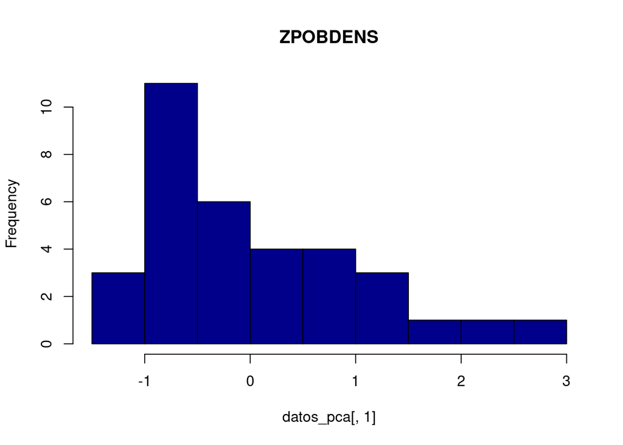

```r
hist(col="darkblue",datos_pca[,1],main="ZPOBDENS")
```

Las medidas resistentes de centralidad están ligeramente desplazadas hacia la izquierda. Tenemos un valor del *MEDA* inferior al de la desviación típica. En los estimadores de simetría, obtenemos que existe cierta asimetría, y el valor de *kurtosis* indica una acumulación de los datos.

**ZMINFAN**

```r
descriptivo(datos_pca[,2])
```

```
## $centralidad
## $centralidad$clasica
## $centralidad$clasica$media
## [1] 8.982296e-17
##
##
## $centralidad$resistente
##                   [,1]
## PMC         -0.0300511
## Trimedia    -0.2115862
## Centrimedia -0.2268480
##
##
## $dispersion
## $dispersion$clasica
## $dispersion$clasica$desviación_típica
## [1] 1
##
## $dispersion$clasica$Coef_varización
## [1] 1.113301e+16
##
## $dispersion$clasica$rango
## [1] -1.102554  1.904824
##
##
## $dispersion$resistente
##                                75%
## Rango Inter-Cuartílico   1.8571199
## MEDA                     0.6040459
## CVc                    -30.8993711
##
##
## $forma
## $forma$clasica
## $forma$clasica$skewness
## [1] 0.5733687
##
## $forma$clasica$kurtosis
## [1] -1.202237
##
##
## $forma$resistente
##                                        25%
## Asimetría de Yule               -0.9235577
## Asimetría de Kelly              -0.6132994
## Asimetría de Kelly adimensional  1.5600769
```

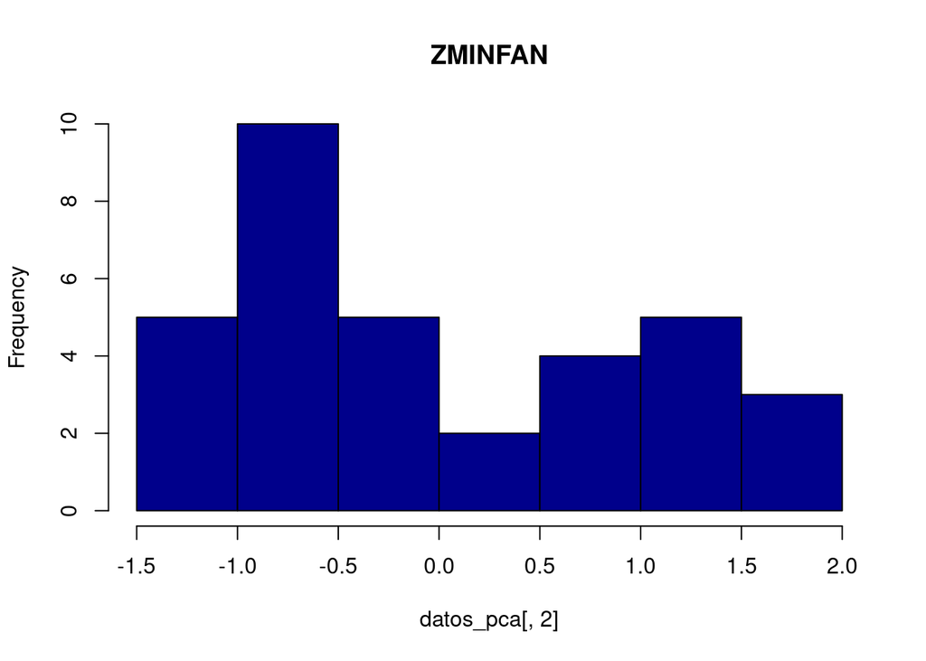

```r
hist(col="darkblue",datos_pca[,2],main="ZMINFAN")
```

Lo primero que llama la atención en el histograma es que a prmera vista parecen dos normales pegadas, pero esto puede deberse a que tenemos muy pocos datos en el conjunto a estudiar y sea una normal con una cola larga.

La media se encuentra ligeramente desviada a la izquierda, y de nuevo la MEDA es menor que la desviación típica.

Vemos en el coeficiente de curtosis que la distribución es muy aplanada y asimetría, lo que se corresponde con el histograma.

**ZESPVIDA**

```r
descriptivo(datos_pca[,3])
```

```
## $centralidad
## $centralidad$clasica
## $centralidad$clasica$media
## [1] -1.72884e-16
##
##
## $centralidad$resistente
##                   [,1]
## PMC         0.07863105
## Trimedia    0.17836465
## Centrimedia 0.17613181
##
##
## $dispersion
## $dispersion$clasica
## $dispersion$clasica$desviación_típica
## [1] 1
##
## $dispersion$clasica$Coef_varización
## [1] -5.784225e+15
##
## $dispersion$clasica$rango
## [1] -2.145279  1.248640
##
##
## $dispersion$resistente
##                               75%
## Rango Inter-Cuartílico  1.6493257
## MEDA                    0.7621433
## CVc                    10.4877506
##
##
## $forma
## $forma$clasica
## $forma$clasica$skewness
## [1] -0.6073997
##
## $forma$clasica$kurtosis
## [1] -0.7827668
##
##
## $forma$resistente
##                                        25%
## Asimetría de Yule               -0.7172544
## Asimetría de Kelly               0.4995611
## Asimetría de Kelly adimensional  1.7963476
```

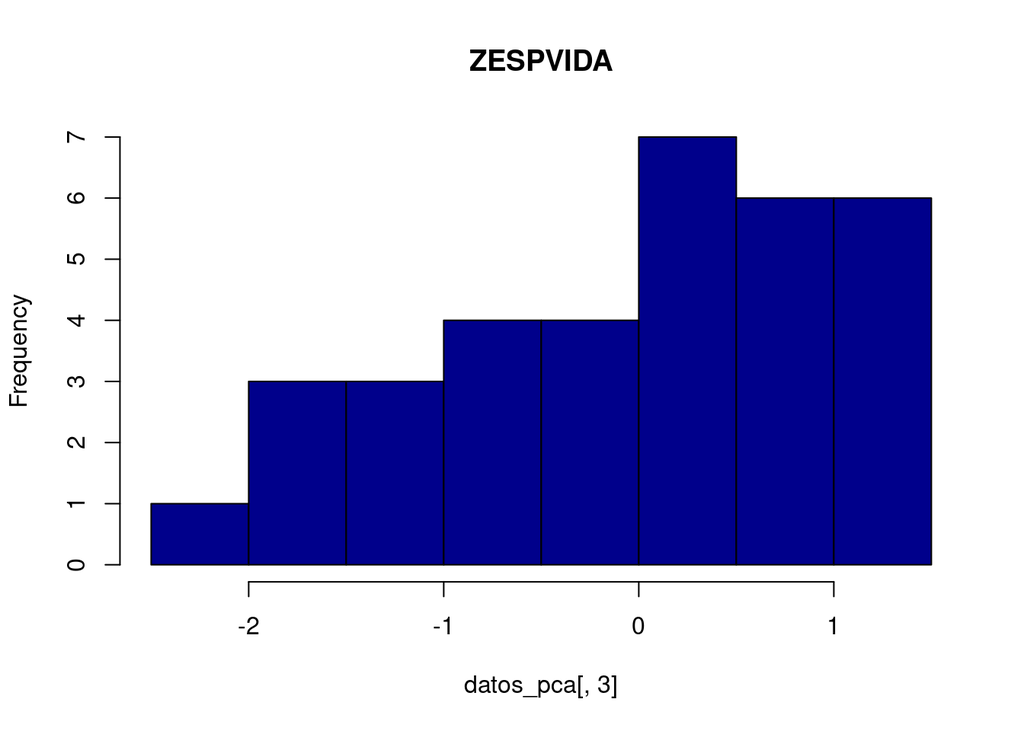

```r
hist(col="darkblue",datos_pca[,3],main="ZESPVIDA")
```

Las medidas de centralidad se encuentran desplazadas a la derecha, y la MEDA vuelve a ser menor que la desviación típica. De nuevo mirando el coeficiente de curtosis vemos una distribución bastante aplanada y con asimetría.

**ZPOBURB**

```r
descriptivo(datos_pca[,4])
```

```
## $centralidad
## $centralidad$clasica
## $centralidad$clasica$media
## [1] 4.511206e-16
##
##
## $centralidad$resistente
##                  [,1]
## PMC         0.0413792
## Trimedia    0.0840905
## Centrimedia 0.1147624
##
##
## $dispersion
## $dispersion$clasica
## $dispersion$clasica$desviación_típica
## [1] 1
##
## $dispersion$clasica$Coef_varización
## [1] 2.216702e+15
##
## $dispersion$clasica$rango
## [1] -1.769694  1.509616
##
##
## $dispersion$resistente
##                               75%
## Rango Inter-Cuartílico  1.5467796
## MEDA                    0.7223655
## CVc                    18.6903015
##
##
## $forma
## $forma$clasica
## $forma$clasica$skewness
## [1] -0.3339002
##
## $forma$clasica$kurtosis
## [1] -1.07826
##
##
## $forma$resistente
##                                        25%
## Asimetría de Yule               -0.6736702
## Asimetría de Kelly               0.2958259
## Asimetría de Kelly adimensional  2.3329787
```

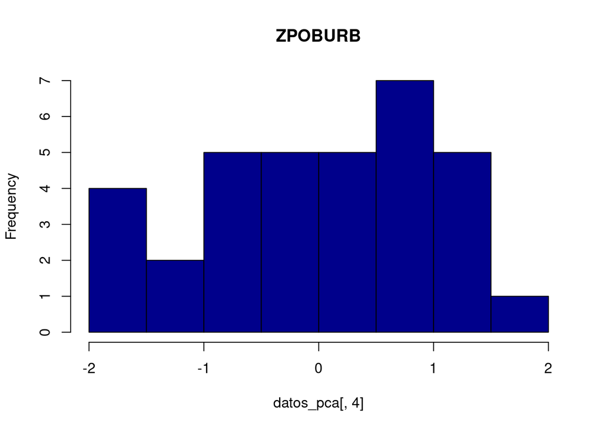

```r
hist(col="darkblue",datos_pca[,4],main="ZPOBURB")
```

Esta distribución parece bastante plana mirando el histograma, ningún valor parece predominar demasiado sobre los otros, pero de nuevo se necesitarían más datos para confirmar.

La media y medidas de centralidad están muy cercanas a 0 y la curtosis indica que la distribución es bastante plana.

**ZTMEDICO**

```r
descriptivo(datos_pca[,5])
```

```
## $centralidad
## $centralidad$clasica
## $centralidad$clasica$media
## [1] 2.416495e-17
##
##
## $centralidad$resistente
##                     [,1]
## PMC         -0.006716126
## Trimedia    -0.149133349
## Centrimedia -0.149734266
##
##
## $dispersion
## $dispersion$clasica
## $dispersion$clasica$desviación_típica
## [1] 1
##
## $dispersion$clasica$Coef_varización
## [1] 4.138224e+16
##
## $dispersion$clasica$rango
## [1] -1.147256  2.371712
##
##
## $dispersion$resistente
##                                 75%
## Rango Inter-Cuartílico    1.7522727
## MEDA                      0.7980172
## CVc                    -130.4526316
##
##
## $forma
## $forma$clasica
## $forma$clasica$skewness
## [1] 0.5139514
##
## $forma$clasica$kurtosis
## [1] -0.8884781
##
##
## $forma$resistente
##                                        25%
## Asimetría de Yule               -0.9769641
## Asimetría de Kelly              -0.3735297
## Asimetría de Kelly adimensional  1.2811833
```

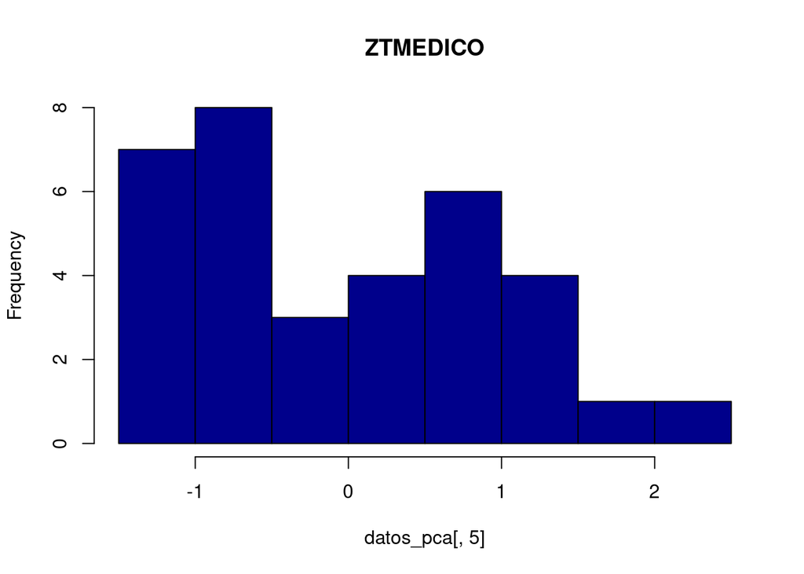

```r
hist(col="darkblue",datos_pca[,5],main="ZTMEDICO")
```

Las medidas de centralidad se encuentran desplazadas hacia la izquierda y el CVc tiene un valor muy bajo. La curtosis indica que la distribución es plana

También llama la atención como las dos primeras columnas son muy altas y a partir de ellas el resto del histograma se asemeja más a una normal.

**ZPAGRICU**

```r
descriptivo(datos_pca[,6])
```

```
## $centralidad
## $centralidad$clasica
## $centralidad$clasica$media
## [1] 6.355338e-17
##
##
## $centralidad$resistente
##                    [,1]
## PMC         -0.06825485
## Trimedia    -0.14081091
## Centrimedia -0.20433276
##
##
## $dispersion
## $dispersion$clasica
## $dispersion$clasica$desviación_típica
## [1] 1
##
## $dispersion$clasica$Coef_varización
## [1] 1.57348e+16
##
## $dispersion$clasica$rango
## [1] -1.234234  1.905157
##
##
## $dispersion$resistente
##                                75%
## Rango Inter-Cuartílico   1.5595319
## MEDA                     0.7069276
## CVc                    -11.4243309
##
##
## $forma
## $forma$clasica
## $forma$clasica$skewness
## [1] 0.6194981
##
## $forma$clasica$kurtosis
## [1] -0.8999068
##
##
## $forma$resistente
##                                        25%
## Asimetría de Yule               -0.6801059
## Asimetría de Kelly              -0.4817497
## Asimetría de Kelly adimensional  2.2578456
```

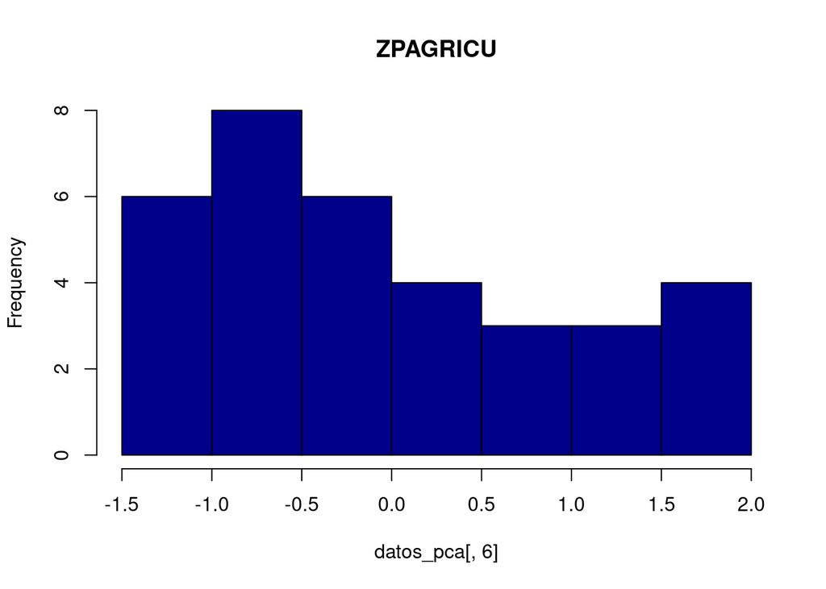

```r
hist(col="darkblue",datos_pca[,6],main="ZPAGRICU")
```

En este caso el histograma se asemeja más al de una normal que en las anteriores variables estudiadas, pese a que se aprecia una asimetría y distribución bastante plana.

Las medidas de centralidad están desviadas ligeramente a la izquierda y la curtosis indica que la distribución es bastante plana.

**ZPSERVI**

```r
descriptivo(datos_pca[,7])
```

```
## $centralidad
## $centralidad$clasica
## $centralidad$clasica$media
## [1] -3.529078e-17
##
##
## $centralidad$resistente
##                     [,1]
## PMC         0.0615893232
## Trimedia    0.0485015920
## Centrimedia 0.0006495749
##
##
## $dispersion
## $dispersion$clasica
## $dispersion$clasica$desviación_típica
## [1] 1
##
## $dispersion$clasica$Coef_varización
## [1] -2.833601e+16
##
## $dispersion$clasica$rango
## [1] -1.885211  1.628845
##
##
## $dispersion$resistente
##                               75%
## Rango Inter-Cuartílico  1.5803435
## MEDA                    0.7918077
## CVc                    12.8296875
##
##
## $forma
## $forma$clasica
## $forma$clasica$skewness
## [1] -0.1297167
##
## $forma$clasica$kurtosis
## [1] -1.068007
##
##
## $forma$resistente
##                                        25%
## Asimetría de Yule               0.73913043
## Asimetría de Kelly              0.05071496
## Asimetría de Kelly adimensional 1.43206522
```

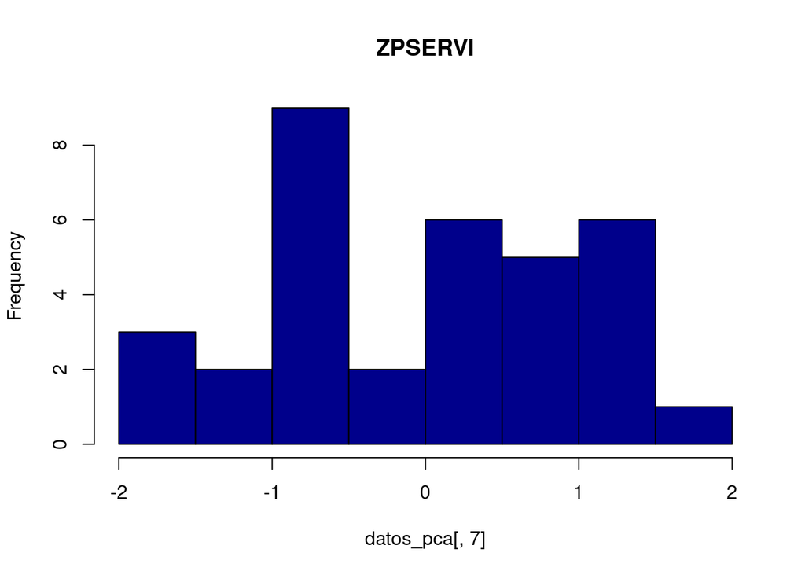

```r
hist(col="darkblue",datos_pca[,7],main="ZPSERVI")
```

Observamos que las medidas de centralidad están desviadas a la derecha, el MEDA es menor que la desviación típica y la curtosis indica que la distribución es plana.

Además, es claro viendo el histograma que la distribución no se asemeja demasiado a la normal, y es posible que la última columna, al tener frecuencia 1, se trae de un outlier.

**ZTLIBROP**

```r
descriptivo(datos_pca[,8])
```

```
## $centralidad
## $centralidad$clasica
## $centralidad$clasica$media
## [1] 6.729069e-17
##
##
## $centralidad$resistente
##                   [,1]
## PMC         -0.1111009
## Trimedia    -0.1776580
## Centrimedia -0.2615358
##
##
## $dispersion
## $dispersion$clasica
## $dispersion$clasica$desviación_típica
## [1] 0.9847319
##
## $dispersion$clasica$Coef_varización
## [1] 1.4634e+16
##
## $dispersion$clasica$rango
## [1] -0.9696156  2.4023604
##
##
## $dispersion$resistente
##                               75%
## Rango Inter-Cuartílico  1.6067690
## MEDA                    0.6849277
## CVc                    -7.2311230
##
##
## $forma
## $forma$clasica
## $forma$clasica$skewness
## [1] 0.8552831
##
## $forma$clasica$kurtosis
## [1] -0.3544396
##
##
## $forma$resistente
##                                        25%
## Asimetría de Yule               -0.5450695
## Asimetría de Kelly              -0.5339910
## Asimetría de Kelly adimensional  2.1865595
```

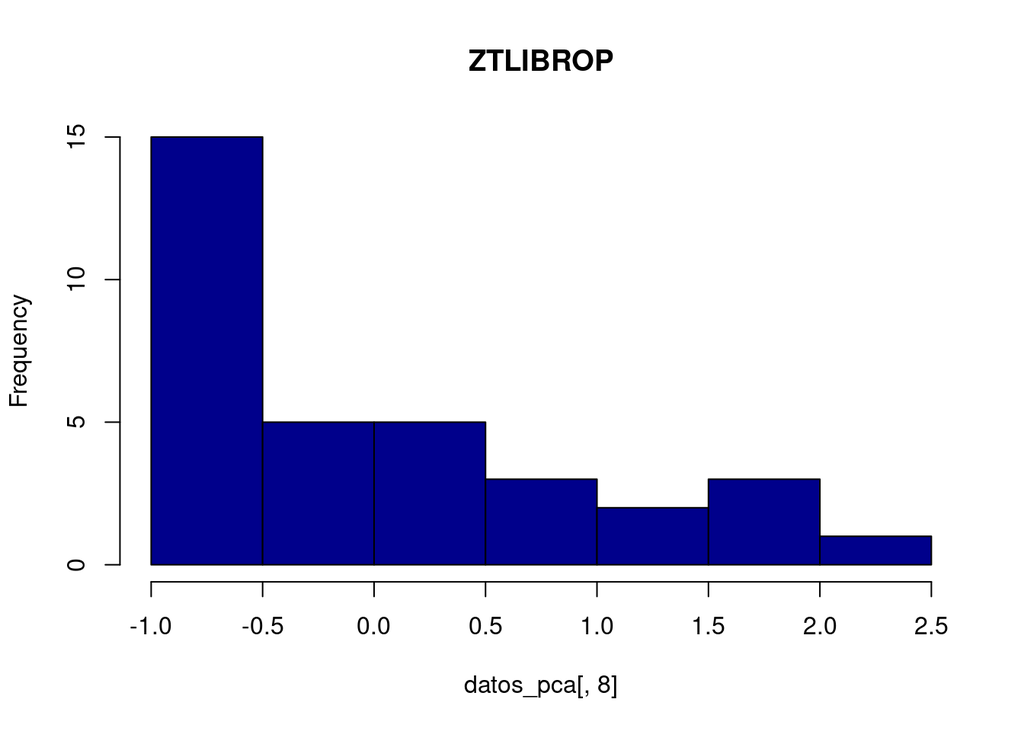

```r
hist(col="darkblue",datos_pca[,8],main="ZTLIBROP")
```

De nuevo ne este caso las medidas de centralidad están desviadas a la izquierda, además se denota una fuerte asimetría en la distribución.

**ZTEJERCI** (variable con conclusiones sesgadas)

```r
descriptivo(datos_pca[,9])
```

```
## $centralidad
## $centralidad$clasica
## $centralidad$clasica$media
## [1] 1.859184e-16
##
##
## $centralidad$resistente
##                   [,1]
## PMC         -0.2594621
## Trimedia    -0.2328606
## Centrimedia -0.2192510
##
##
## $dispersion
## $dispersion$clasica
## $dispersion$clasica$desviación_típica
## [1] 1
##
## $dispersion$clasica$Coef_varización
## [1] 5.378705e+15
##
## $dispersion$clasica$rango
## [1] -0.8658606  4.4262018
##
##
## $dispersion$resistente
##                               75%
## Rango Inter-Cuartílico  0.6788462
## MEDA                    0.3313997
## CVc                    -1.3081800
##
##
## $forma
## $forma$clasica
## $forma$clasica$skewness
## [1] 2.999371
##
## $forma$clasica$kurtosis
## [1] 11.41767
##
##
## $forma$resistente
##                                        25%
## Asimetría de Yule                0.2579423
## Asimetría de Kelly              -0.3448882
## Asimetría de Kelly adimensional  1.6721112
```

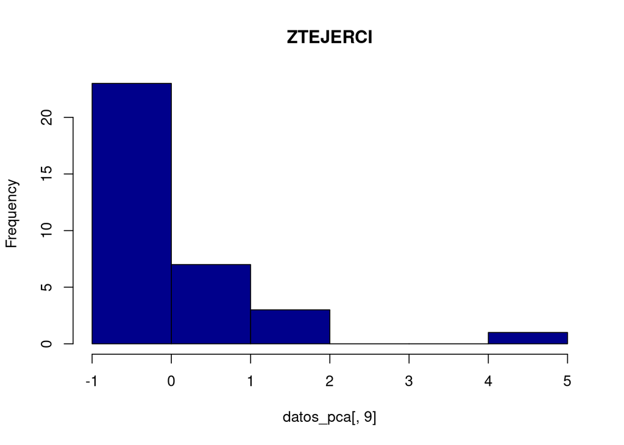

```r
hist(col="darkblue",datos_pca[,9],main="ZTEJERCI")
```

En este caso tenemos unas medidas de centralidad muy desviadas a la izquierda, con una fuerte asimetría y una concentración de datos muy alta en la primera columna.

El rango de esta variable es mucho más amplio que el de todas las demás, y resulta llamativo como los últimos valores de la derecha no tienen una frecuencia alta, haciendo sospechar de que sean outliers.

**ZTPOBACT**

```r
descriptivo(datos_pca[,10])
```

```
## $centralidad
## $centralidad$clasica
## $centralidad$clasica$media
## [1] -2.952027e-16
##
##
## $centralidad$resistente
##                    [,1]
## PMC          0.10268877
## Trimedia    -0.00198850
## Centrimedia  0.02917055
##
##
## $dispersion
## $dispersion$clasica
## $dispersion$clasica$desviación_típica
## [1] 1
##
## $dispersion$clasica$Coef_varización
## [1] -3.387502e+15
##
## $dispersion$clasica$rango
## [1] -2.134094  1.704472
##
##
## $dispersion$resistente
##                              75%
## Rango Inter-Cuartílico 1.5523378
## MEDA                   0.8557514
## CVc                    7.5584589
##
##
## $forma
## $forma$clasica
## $forma$clasica$skewness
## [1] -0.1344579
##
## $forma$clasica$kurtosis
## [1] -0.8348377
##
##
## $forma$resistente
##                                         25%
## Asimetría de Yule               -1.96271531
## Asimetría de Kelly              -0.06440751
## Asimetría de Kelly adimensional  0.60382547
```

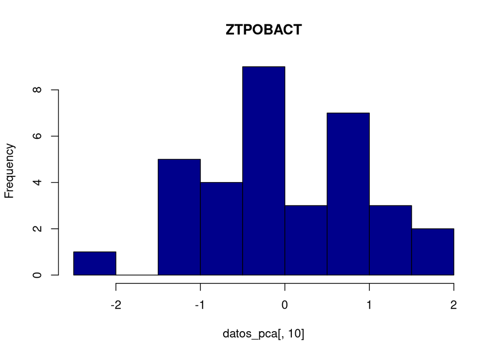

```r
hist(col="darkblue",datos_pca[,10],main="ZTPOBACT")
```

Esta distribución se parece más a una normal que algunas de las estudiadas anteriormente, está más centrada (sus medidas de centralidad son más cercanas a 0) y su curtosis es baja, lo que indica una distribución aplanada.

Mirando el histograma apreciamos algunos valores cerca de -2 que pueden parecer outliers por su separación con el resto de los valores representados.

**ZTENERGI**

```r
descriptivo(datos_pca[,11])
```

```
## $centralidad
## $centralidad$clasica
## $centralidad$clasica$media
## [1] 3.586955e-17
##
##
## $centralidad$resistente
##                    [,1]
## PMC         -0.09924855
## Trimedia    -0.24461072
## Centrimedia -0.26271176
##
##
## $dispersion
## $dispersion$clasica
## $dispersion$clasica$desviación_típica
## [1] 1
##
## $dispersion$clasica$Coef_varización
## [1] 2.78788e+16
##
## $dispersion$clasica$rango
## [1] -0.950661  2.749785
##
##
## $dispersion$resistente
##                              75%
## Rango Inter-Cuartílico  1.364062
## MEDA                    0.520457
## CVc                    -6.871948
##
##
## $forma
## $forma$clasica
## $forma$clasica$skewness
## [1] 1.284408
##
## $forma$clasica$kurtosis
## [1] 1.262001
##
##
## $forma$resistente
##                                        25%
## Asimetría de Yule               -0.7454988
## Asimetría de Kelly              -0.5056537
## Asimetría de Kelly adimensional  1.2966382
```

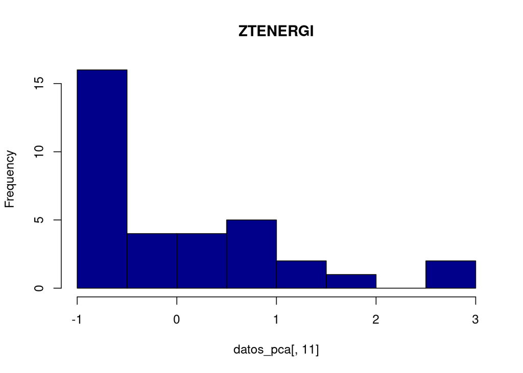

```r
hist(col="darkblue",datos_pca[,11],main="ZTENERGI")
```

Al igual que en uno de los casos anteriores tenemos las medidas de centralidad desviadas a la izquierda, una curtosis bastante alta y un rango de valores amplio, con algunos separados de los demás en los extremos que parecen outliers.

**NOTAR**: el hecho de que algunas de las variables estén desplazadas hacia la derecha, o que los outliers sean en esta dirección, es debido a que estas son estandarizaciones de variables positivas, en una variable positiva el valor mas extremo inferior como mucho es $0$.

Las que si tienen extensión hacia la izquierda, es debido a que no hay un gran porcentaje de la población que se acerque al extremo inferior, entonces el $0$ realmente si acaba siendo un valor “extremo” para estas variables.

## Exploración Gráfica

Procedemos con los diagramas de cajas y bigotes, para una detección primaria de outliers univariantes.

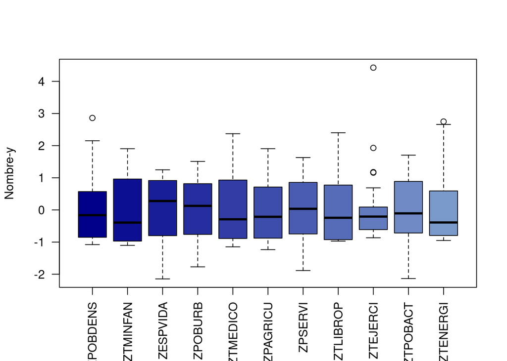

```r
colfunc<-colorRampPalette(c("darkblue","lightblue"))
boxplot(datos_pca,
        xlab=NULL,
        ylab="Nombre-y",
        col=colfunc(15),
        las=2)
```

Se puede observar que la mayoría de gráficos se asemejan en cierto modo a una normal,estando todos ligeramente desplazados, y destacando que POBDENS y ZTEJERCI tienen una mayor concentración de valores. La mayoría de outliers se encuentran en ZTEJERCI como cola superior.

Pese a que algunas de las distribuciones de las variables que presentan outliers no se parecen demasiado a una normal, se ha tomado la decisión de eliminarlos, a pesar de que pueda no ser lo más correcto, ya que boxplot asume que la distribución es normal y en algunos casos esto parece dudoso.

A continuación vamos a observar (de nuevo) la forma de las distribuciones de las variables mediante sus histogramas

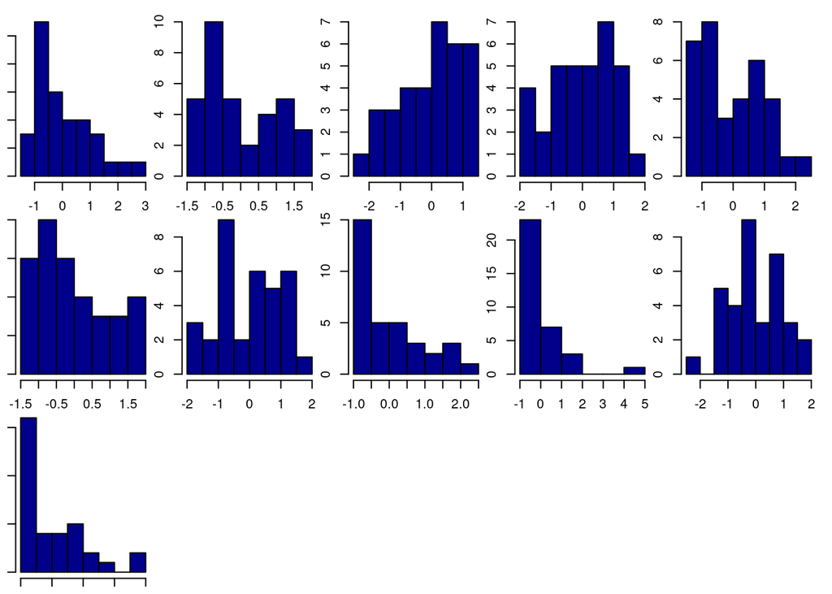

```r
par(mar=c(1,1,1,1))
par(mfrow=c(3,5))
invisible(apply(datos_pca, 2,function(x){hist(x,main=NULL,col="darkblue",xlab=NULL,ylab=NULL)}))
```

Observamos que realmente pocas de las variables realmente se podrían considerar normales con los datos que tenemos, pero son muy pocos, por lo que quizá al recoger una muestra mayor de observaciones se podrían sacar mejores conclusiones sobre las distribuciones de las variables.